# CS 422 - Homework 1

Juan Luis Polo Garzon, Student, Illinois Institute of Technology

# Programming Problems

## Problem 1

#### Section A

```r
setwd("/Users/juanluispolog/Google Drive/CS422/homework1")
```

```
The working directory was changed to /Users/juanluispolog/Google Drive/CS422/homework1 inside a notebook chunk. The working directory will be reset when the chunk is finished running. Use the knitr root.dir option in the setup chunk to change the working directory for notebook chunks.
```

```r
college.df <- read.csv("College.csv")
head(college.df)
```

|  | Name | Private | Apps | Accept | Enroll | Top10perc | Top25perc | F.Undergrad | P.Undergrad | Outstate | Room.Board | Books | Personal | PhD | Terminal | S.F.Ratio | perc.alumni | Expend | Grad.Rate |
| --- | --- | --- | --- | --- | --- | --- | --- | --- | --- | --- | --- | --- | --- | --- | --- | --- | --- | --- | --- |
| 1 | Abilene Christian University | Yes | 1660 | 1232 | 721 | 23 | 52 | 2885 | 537 | 7440 | 3300 | 450 | 2200 | 70 | 78 | 18.1 | 12 | 7041 | 60 |
| 2 | Adelphi University | Yes | 2186 | 1924 | 512 | 16 | 29 | 2683 | 1227 | 12280 | 6450 | 750 | 1500 | 29 | 30 | 12.2 | 16 | 10527 | 56 |
| 3 | Adrian College | Yes | 1428 | 1097 | 336 | 22 | 50 | 1036 | 99 | 11250 | 3750 | 400 | 1165 | 53 | 66 | 12.9 | 30 | 8735 | 54 |
| 4 | Agnes Scott College | Yes | 417 | 349 | 137 | 60 | 89 | 510 | 63 | 12960 | 5450 | 450 | 875 | 92 | 97 | 7.7 | 37 | 19016 | 59 |
| 5 | Alaska Pacific University | Yes | 193 | 146 | 55 | 16 | 44 | 249 | 869 | 7560 | 4120 | 800 | 1500 | 76 | 72 | 11.9 | 2 | 10922 | 15 |
| 6 | Albertson College | Yes | 587 | 479 | 158 | 38 | 62 | 678 | 41 | 13500 | 3335 | 500 | 675 | 67 | 73 | 9.4 | 11 | 9727 | 55 |

#### Section B

```r
library(dplyr)

Priv <- table(college.df$Private)
Priv
```

```
 No Yes
212 565
```

#### Section C

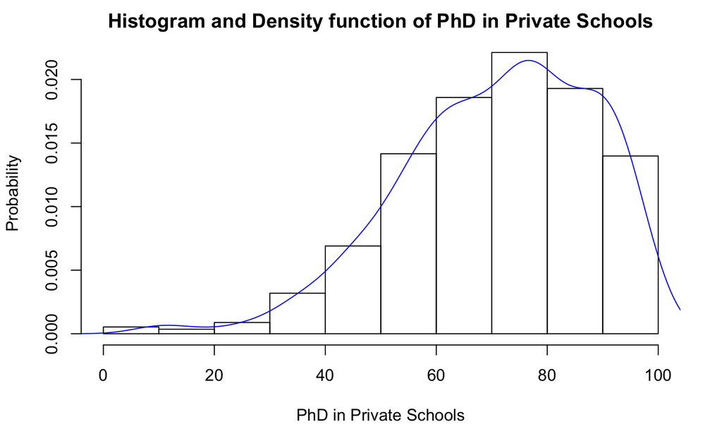

```r
private <- filter(college.df, Private == "Yes")
public <- filter(college.df, Private == "No")
hist(private$PhD, probability = T, xlab = "PhD in Private Schools",
     ylab = "Probability",
     main="Histogram and Density function of PhD in Private Schools")
lines(density(private$PhD), col="blue")
```

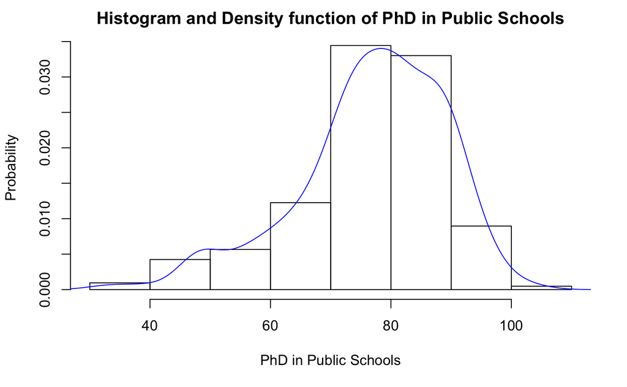

```r
hist(public$PhD, probability = T, xlab = "PhD in Public Schools", ylab = "Probability",
     main="Histogram and Density function of PhD in Public Schools")
lines(density(public$PhD), col="blue")
```

In order to be able to valuate more consistently, the summaries of both attributes are calculated:

```r
summary(private$PhD)
```

```
   Min. 1st Qu.  Median    Mean 3rd Qu.    Max.
   8.00   60.00   73.00   71.09   85.00  100.00
```

```r
summary(public$PhD)
```

```
   Min. 1st Qu.  Median    Mean 3rd Qu.    Max.
  33.00   71.00   78.50   76.83   86.00  103.00
```

From histograms it could be inferred that there is no significant difference between employed PhDs in private and public universities. However, by adding all the PhDs employed in both types of universities, it is observed that the private university has more PhDs than the public.

#### Section D

The following instruction creates the dataframe college.df.grad, where the data is sorted according to the Grad.Rate attribute (from lowest to highest)

```r
college.df.grad <- arrange(college.df, Grad.Rate)
```

The following instructions print the top 5 universities with the minimum graduation rates, and the top 5 with the maximum graduation rates.

```r
head(select(college.df.grad, Name, Grad.Rate), n=5)
```

|  | Name | Grad.Rate |
| --- | --- | --- |
| 1 | Texas Southern University | 10 |
| 2 | Alaska Pacific University | 15 |
| 3 | Montreat-Anderson College | 15 |
| 4 | Brewton-Parker College | 18 |
| 5 | Claflin College | 21 |

```r
tail(select(college.df.grad, Name, Grad.Rate), n=5)
```

|  | Name | Grad.Rate |
| --- | --- | --- |
| 773 | Missouri Southern State College | 100 |
| 774 | Santa Clara University | 100 |
| 775 | Siena College | 100 |
| 776 | University of Richmond | 100 |
| 777 | Cazenovia College | 118 |

The top 5 universities with the highest graduation rates are ordered the other way around, from lowest to highest. To reverse it it is possible to use *desc()* fuction:

```r
head(select(arrange(college.df, desc(Grad.Rate)), Name, Grad.Rate), n=5)
```

|  | Name | Grad.Rate |
| --- | --- | --- |
| 1 | Cazenovia College | 118 |
| 2 | Amherst College | 100 |
| 3 | College of Mount St. Joseph | 100 |
| 4 | Grove City College | 100 |
| 5 | Harvard University | 100 |

#### Section E

##### E - I

Numerical summary of the variables in the data set *college.df*

```r
summary(college.df)
```

```
                           Name     Private        Apps           Accept          Enroll
 Abilene Christian University:  1   No :212   Min.   :   81   Min.   :   72   Min.   :  35
 Adelphi University          :  1   Yes:565   1st Qu.:  776   1st Qu.:  604   1st Qu.: 242
 Adrian College              :  1             Median : 1558   Median : 1110   Median : 434
 Agnes Scott College         :  1             Mean   : 3002   Mean   : 2019   Mean   : 780
 Alaska Pacific University   :  1             3rd Qu.: 3624   3rd Qu.: 2424   3rd Qu.: 902
 Albertson College           :  1             Max.   :48094   Max.   :26330   Max.   :6392
 (Other)                     :771
   Top10perc       Top25perc      F.Undergrad     P.Undergrad         Outstate
 Min.   : 1.00   Min.   :  9.0   Min.   :  139   Min.   :    1.0   Min.   : 2340
 1st Qu.:15.00   1st Qu.: 41.0   1st Qu.:  992   1st Qu.:   95.0   1st Qu.: 7320
 Median :23.00   Median : 54.0   Median : 1707   Median :  353.0   Median : 9990
 Mean   :27.56   Mean   : 55.8   Mean   : 3700   Mean   :  855.3   Mean   :10441
 3rd Qu.:35.00   3rd Qu.: 69.0   3rd Qu.: 4005   3rd Qu.:  967.0   3rd Qu.:12925
 Max.   :96.00   Max.   :100.0   Max.   :31643   Max.   :21836.0   Max.   :21700

   Room.Board       Books           Personal         PhD            Terminal
 Min.   :1780   Min.   :  96.0   Min.   : 250   Min.   :  8.00   Min.   : 24.0
 1st Qu.:3597   1st Qu.: 470.0   1st Qu.: 850   1st Qu.: 62.00   1st Qu.: 71.0
 Median :4200   Median : 500.0   Median :1200   Median : 75.00   Median : 82.0
 Mean   :4358   Mean   : 549.4   Mean   :1341   Mean   : 72.66   Mean   : 79.7
 3rd Qu.:5050   3rd Qu.: 600.0   3rd Qu.:1700   3rd Qu.: 85.00   3rd Qu.: 92.0
 Max.   :8124   Max.   :2340.0   Max.   :6800   Max.   :103.00   Max.   :100.0

   S.F.Ratio      perc.alumni        Expend        Grad.Rate
 Min.   : 2.50   Min.   : 0.00   Min.   : 3186   Min.   : 10.00
 1st Qu.:11.50   1st Qu.:13.00   1st Qu.: 6751   1st Qu.: 53.00
 Median :13.60   Median :21.00   Median : 8377   Median : 65.00
 Mean   :14.09   Mean   :22.74   Mean   : 9660   Mean   : 65.46
 3rd Qu.:16.50   3rd Qu.:31.00   3rd Qu.:10830   3rd Qu.: 78.00
 Max.   :39.80   Max.   :64.00   Max.   :56233   Max.   :118.00
```

##### E - II

Scatterplot matrix of the first ten attributes of the data.

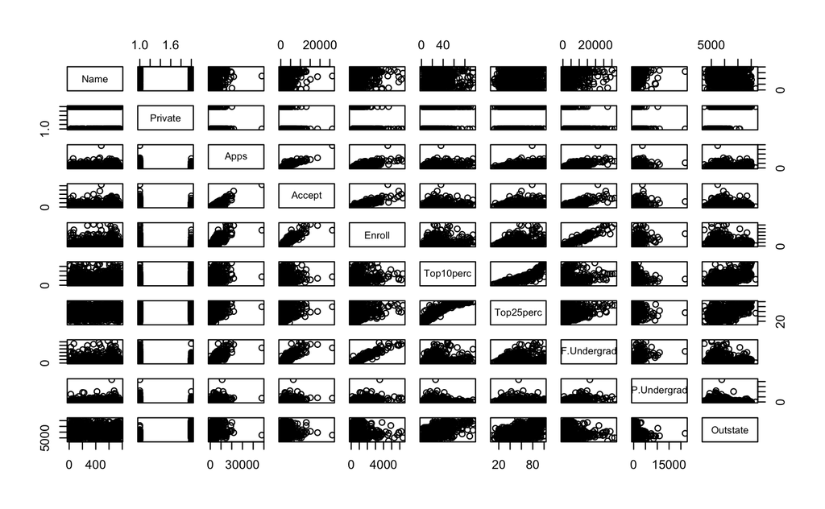

```r
pairs(college.df[,1:10])
```

##### E - III

Side-by-side boxplots for compare which alumni donate more to their colleges, public college or private college students.

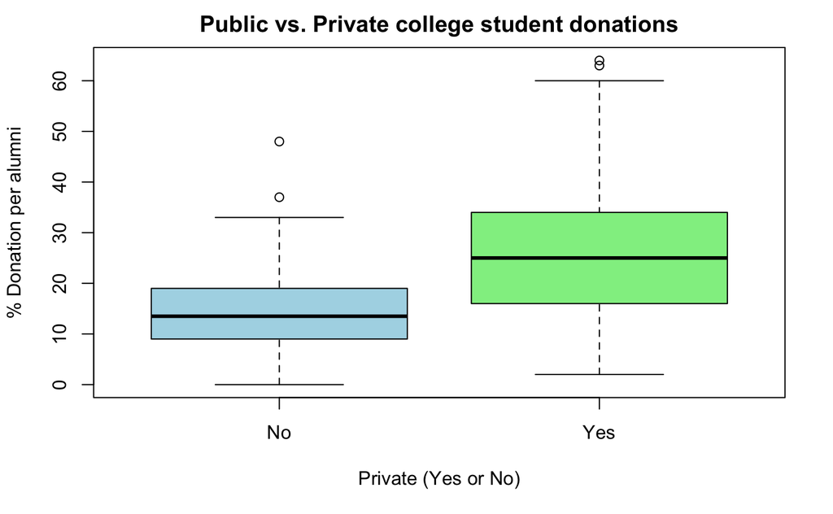

```r
boxplot(college.df$perc.alumni ~ college.df$Private, col=c("lightblue", "lightgreen"),
        xlab = "Private (Yes or No)", ylab = "% Donation per alumni",
        main="Public vs. Private college student donations")
```

Both Q1 and IQR in private universities are higher than in public universities. It can be concluded that student donations to **private** universities are higher. It could be verified by calculating the mean value:

```r
mean((filter(college.df, Private == "Yes"))$perc.alumni)
```

```
[1] 25.89027
```

```r
mean((filter(college.df, Private == "No"))$perc.alumni)
```

```
[1] 14.35849
```

It is clear that the average donation per student at private universities is much higher than at public universities.

##### E - IV

Side-by-side boxplots for compare which type of college employ more PhD’s:

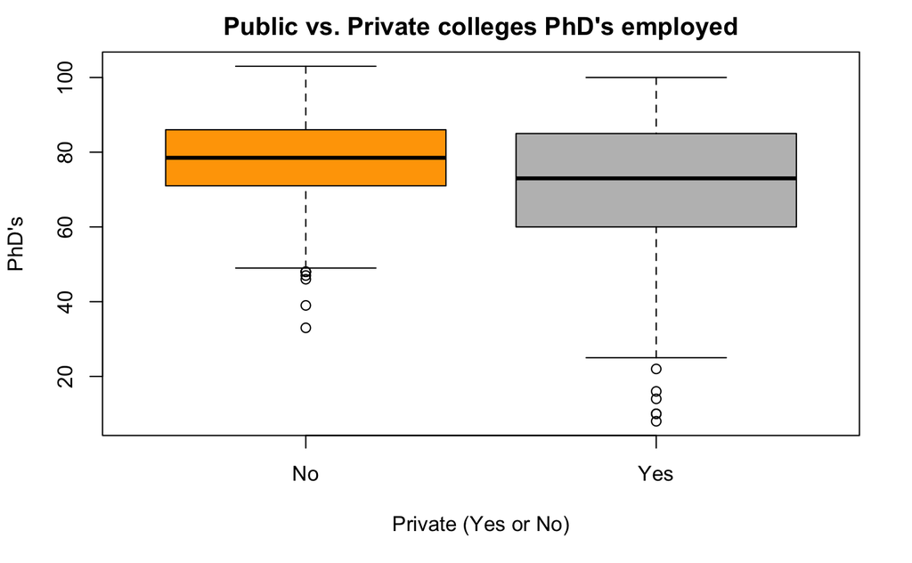

```r
boxplot(college.df$PhD ~ college.df$Private, col=c("orange", "grey"),
        xlab = "Private (Yes or No)", ylab = "PhD's",
        main="Public vs. Private colleges PhD's employed")
```

```r
mean((filter(college.df, Private == "Yes"))$PhD)
```

```
[1] 71.09381
```

```r
mean((filter(college.df, Private == "No"))$PhD)
```

```
[1] 76.83491
```

Public universities employ more PhDs on average than private universities. However, there are more private than public universities, so the number of PhDs in all of the private universities is higher.

##### E - V

In order to create the Elite attribute:

```r
Elite <- rep("No", nrow(college.df))
Elite[college.df$Top10perc > 50] <- "Yes"
Elite <- as.factor(Elite)
college.df <- data.frame(college.df, Elite)
summary(college.df$Elite)
```

```
 No Yes
699  78
```

There are **78 universities** which can be considered as *elite colleges*.

##### E - VI

These are the variables which are going to be displayed:

- Accept
- Enroll
- Top10perc
- Top25perc
- F.Undergrad
- Expend

```r
par(mfrow=c(2, 3))
hist(public$Accept, probability = T, xlab = "Acceptance", ylab = "Probability",
     main="Acceptance for all colleges", breaks = 10)
hist(public$Enroll, probability = T, xlab = "Enrollment", ylab = "Probability",
     main="Enrollment for all colleges", breaks = 20)
```

```r
hist(public$F.Undergrad, probability = T, xlab = "Number of full-time undergrad students",
     ylab = "Probability",
     main="Full-time undergrad students", breaks = 15)
hist(public$Top10perc, probability = T, xlab = "Number of new students in top 10",
     ylab = "Probability",
     main="% of new students in top 10", breaks = 100)
```

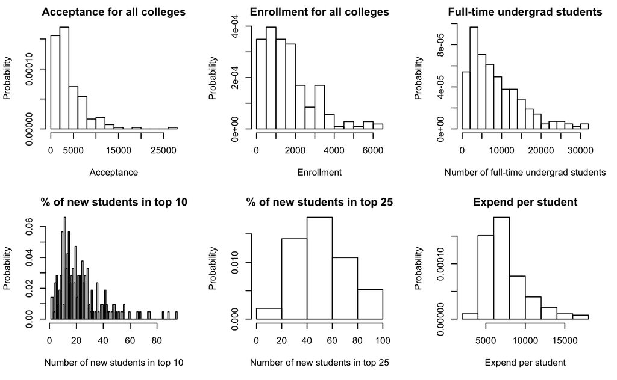

```r
hist(public$Top25perc, probability = T, xlab = "Number of new students in top 25",
     ylab = "Probability",
     main="% of new students in top 25", breaks = 5)
hist(public$Expend, probability = T, xlab = "Expend per student", ylab = "Probability",
     main="Expend per student")
```

##### E - VII

To find the relationship between elite and private schools:

```r
Priv.Elite <- table(college.df$Private, college.df$Elite) #table with the relations between private and elite colleges
Priv.Elite
```

```
       No Yes
  No  199  13
  Yes 500  65
```

Therefore, there are **565 private** colleges, from which **65** are **elite** colleges. There are also **212 public** colleges, from which **13** are **elite** universities. In the plot below, it can be appreciated that the percentage of private schools considered elite is higher than that of public schools.

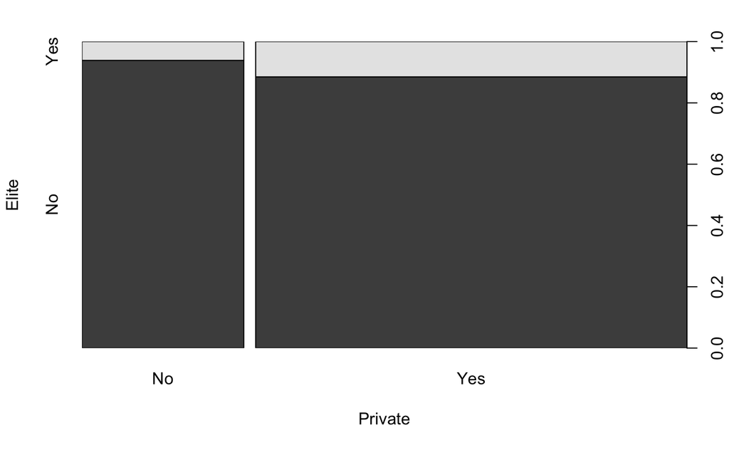

```r
plot(college.df$Private, college.df$Elite, xlab="Private", ylab="Elite")
```

From this plot can be concluded that the percentage of private elite colleges is higher than the percentage of public elite colleges.

## Problem 2

#### Section A

It is needed to remove the *country* variable (name of the country), since is a qualitative variable and it will not be possible to calculate correlations with it.

```r
# Setting the working directory, although the archive goog.csv is in the same location as College.csv from the previous exercise
setwd("/Users/juanluispolog/Google Drive/CS422/homework1")
```

```
The working directory was changed to /Users/juanluispolog/Google Drive/CS422/homework1 inside a notebook chunk. The working directory will be reset when the chunk is finished running. Use the knitr root.dir option in the setup chunk to change the working directory for notebook chunks.
```

```r
google <- read.csv("goog.csv")
google <- google[,-1]
```

#### Section B

Pairwise correlation plot using *pairs.panels()*:

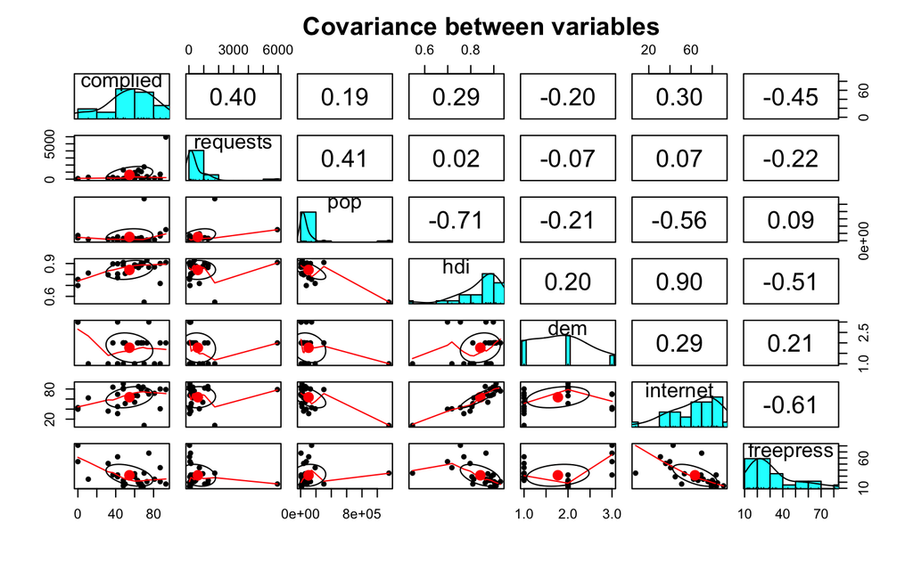

```r
library(psych)
pairs.panels(google)
title(main = "Covariance between variables")
```

It is important to highlight that the response variable is *complied* (number of requests Google complied).

##### B - I

The variable which is more **positive** correlated with the response variable is *requests* (number of requests that Google complied), and it may be due to the more requests, the more requests complied with. Although correlation does not imply causation.

##### B - II

The variable which is more **negative** correlated with the response variable is *freepress* (free press index), and it may be because the larger the free press index in a country, the lesser the value of *freepress* and the more probable to make a search in Google. Although correlation does not imply causation.

##### B - III

The highest **positive** correlation (0.90) between two explanatory variables is produced between *internet* (percentage of internet users in the country) and *hdi* (Human Development Index), and it may be due to the more developed a country, the more people will have access to the Internet. Although correlation does not imply causation.

##### B - IV

The highest **negative** correlation (-0.71) between two explanatory variables is produced between *pop* (population of the country) and *hdi* (Human Development Index), and it may be because population and hdi are inversely related.

#### Section C

The following instrucctions create a multiple linear regression model:

```r
# Mutiple Linear Regression Model
model <- lm(complied ~ ., data = google)
summary(model)
```

```
Call:
lm(formula = complied ~ ., data = google)

Residuals:
    Min      1Q  Median      3Q     Max
-35.666 -11.871  -1.373   6.571  47.290

Coefficients:
              Estimate Std. Error t value Pr(>|t|)
(Intercept) -1.187e+02  1.091e+02  -1.088   0.2911
requests     2.012e-03  4.529e-03   0.444   0.6622
pop          6.698e-05  3.748e-05   1.787   0.0908 .
hdi          2.007e+02  1.540e+02   1.303   0.2090
demfull     -8.371e-01  1.282e+01  -0.065   0.9486
demhybrid   -1.776e+01  1.752e+01  -1.014   0.3241
internet    -2.576e-02  6.018e-01  -0.043   0.9663
freepress    2.866e-02  4.564e-01   0.063   0.9506
---
Signif. codes:  0 ‘***’ 0.001 ‘**’ 0.01 ‘*’ 0.05 ‘.’ 0.1 ‘ ’ 1

Residual standard error: 21.65 on 18 degrees of freedom
Multiple R-squared:  0.4487,    Adjusted R-squared:  0.2343
F-statistic: 2.093 on 7 and 18 DF,  p-value: 0.09797
```

The low value of the adjusted R-squared is remarkable, which indicates that the model is not very fitted.

##### C - I

Considering the previous summary, the most highly significant explanatory variables is *pop* (population of the country) due to their high t-value.

##### C - II

The variance could be explained with the adjusted R-square. Since adjusted R-squared is 0.2343, this is the variance.

##### C - III

As previously commented, the value of adjusted R-square in this model is remarkably low. This means that the model could be improved.

#### Section D

The correlation between the factor variable *dem* and the response variable *complied* is calculated below:

```r
dem.numeric <- as.numeric(google$dem)
cor(google$complied, dem.numeric)
```

```
[1] -0.2030612
```

## Problem 3

Firstly, it is needed to import the nba dataset into a dataframe in R:

```r
nba <- read.csv("nba.csv")
str(nba)
```

```
'data.frame':   269 obs. of  23 variables:
 $ SEASON         : Factor w/ 1 level "2017-2018 Regular Season": 1 1 1 1 1 1 1 1 1 1 ...
 $ DATE           : Factor w/ 2 levels "10/17/2017","10/18/2017": 1 1 1 1 1 1 1 1 1 1 ...
 $ PLAYER.FULLNAME: Factor w/ 254 levels "Aaron Gordon",..: 88 110 3 109 155 171 13 210 223 213 ...
 $ POSITION       : Factor w/ 5 levels "C","PF","PG",..: 4 4 1 4 3 3 1 2 3 3 ...
 $ OWNTEAM        : Factor w/ 24 levels "Atlanta","Boston",..: 2 2 2 2 2 2 2 2 2 2 ...
 $ OPPTEAM        : Factor w/ 24 levels "Atlanta","Boston",..: 5 5 5 5 5 5 5 5 5 5 ...
 $ VENUE          : Factor w/ 2 levels "H","R": 2 2 2 2 2 2 2 2 2 2 ...
 $ MIN            : num  5.3 36.5 32.1 39.6 39.4 35.1 19.1 8.7 19.5 4.8 ...
 $ FG             : int  1 5 2 11 8 5 2 0 2 0 ...
 $ FGA            : int  2 12 7 23 17 16 2 2 6 1 ...
 $ X3P            : int  0 1 0 2 4 0 0 0 1 0 ...
 $ X3PA           : int  1 2 2 9 9 4 0 1 3 1 ...
 $ FT             : int  0 3 5 1 2 2 2 0 4 0 ...
 $ FTA            : int  0 3 7 2 2 3 4 0 4 0 ...
 $ OR             : int  0 4 0 1 2 0 2 0 0 0 ...
 $ DR             : int  1 6 7 5 2 9 3 0 3 1 ...
 $ TOT            : int  1 10 7 6 4 9 5 0 3 1 ...
 $ A              : int  0 3 5 0 10 3 1 0 2 0 ...
 $ PF             : int  1 4 2 5 4 2 5 1 0 0 ...
 $ ST             : int  0 0 0 2 3 2 0 0 4 0 ...
 $ TO             : int  0 1 0 3 2 2 2 0 0 0 ...
 $ BL             : int  0 0 1 0 0 2 1 0 0 0 ...
 $ PTS            : int  2 14 9 25 22 12 6 0 9 0 ...
```

#### Section A

I have chosen the variable *FG* (field goals) because from my point of view it can be the most correlated with *PTS*.

```r
simple.model <- lm(PTS ~ FG, data = nba)
summary(simple.model)
```

```
Call:
lm(formula = PTS ~ FG, data = nba)

Residuals:
    Min      1Q  Median      3Q     Max
-5.7986 -1.2524 -0.3616  0.8569  9.4199

Coefficients:
            Estimate Std. Error t value Pr(>|t|)
(Intercept)  0.58848    0.22751   2.587   0.0102 *
FG           2.55462    0.04715  54.186   <2e-16 ***
---
Signif. codes:  0 ‘***’ 0.001 ‘**’ 0.01 ‘*’ 0.05 ‘.’ 0.1 ‘ ’ 1

Residual standard error: 2.241 on 267 degrees of freedom
Multiple R-squared:  0.9166,    Adjusted R-squared:  0.9163
F-statistic:  2936 on 1 and 267 DF,  p-value: < 2.2e-16
```

Given the small p-value of the predictor and the high value of the t-statistic, we can affirm that the *FG* variable has a **great influence** on *PTS.* This was the expected result.

However, it is not verified that *FG* has the highest correlation with *PTS*. The following plot represents the correlations between all **numeric** variables in *nba* dataframe. All the factor variables are not taking into account.

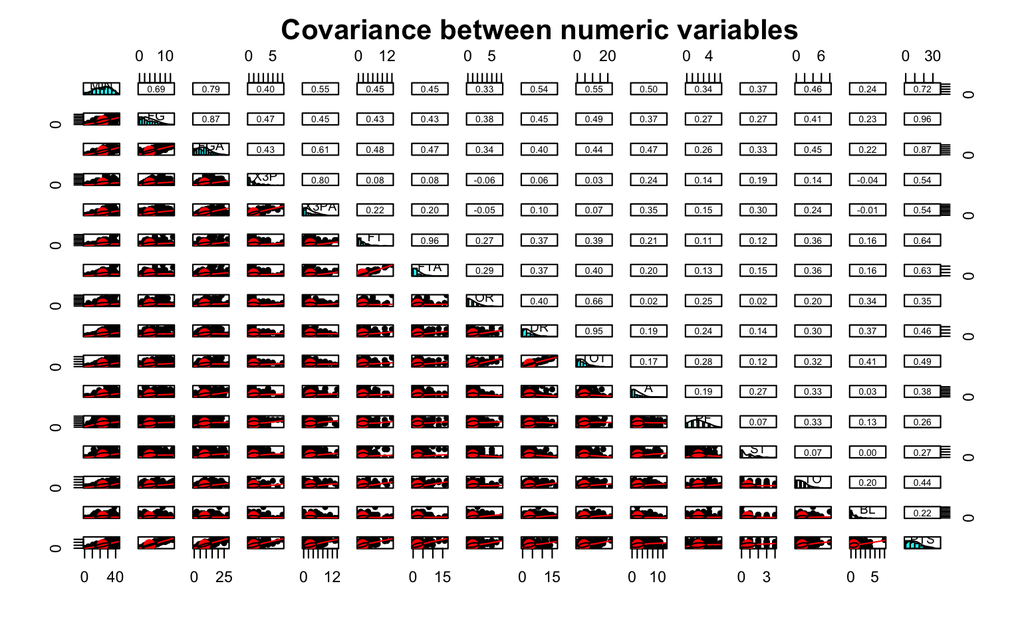

```r
pairs.panels(nba[,8:23])
title(main = "Covariance between numeric variables")
```

As can be seen, the highest correlation between the explanatory variables and the response variable *PTS* is **0.96**, and corresponds to the variable *FG*.

#### Section B

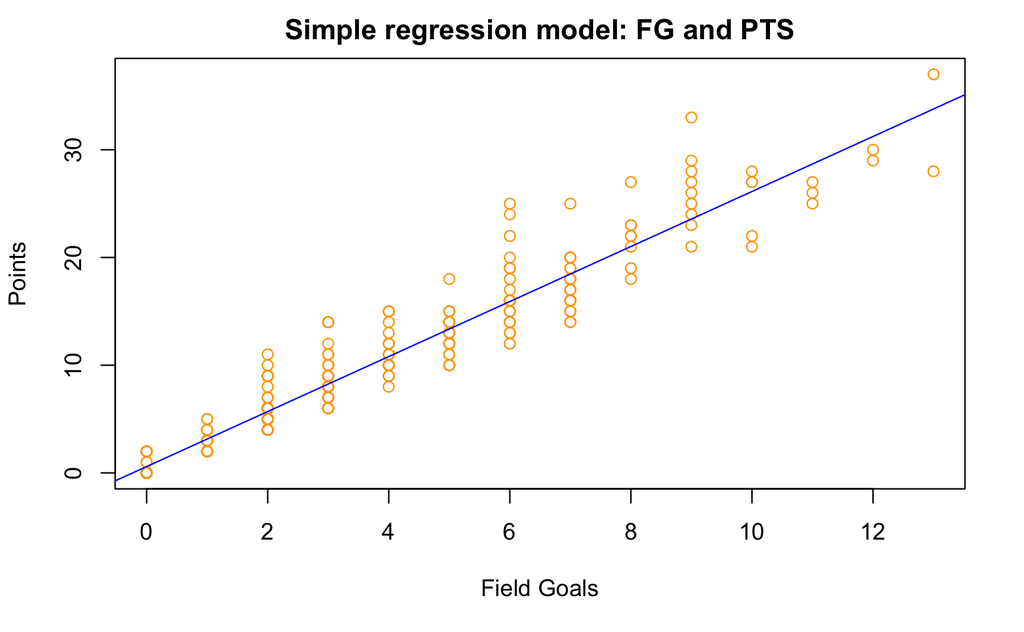

```r
plot(nba$FG, nba$PTS, col = "orange", main = "Simple regression model: FG and PTS",
     xlab = "Field Goals", ylab = "Points")
abline(simple.model, col = "blue")
```

#### Section C

Creating the *train* and *test* dataframes:

```r
set.seed(1122)
index <- sample(1:nrow(nba), 250)
train <- nba[index, ]
test <- nba[-index, ]
```

Taking into consideration the above *pairs.panels()* where correlations are shown, these are the selected variables to create a multiple regression linear model:

- FG
- FGA
- MIN
- FT

The following **regression models** are built with the *train* dataframe.

```r
multi.model1 <- lm(PTS ~ FG + FGA + MIN + FT, data = train)
summary(multi.model1)
```

```
Call:
lm(formula = PTS ~ FG + FGA + MIN + FT, data = train)

Residuals:
    Min      1Q  Median      3Q     Max
-2.3802 -0.7043 -0.1443  0.4947  5.1716

Coefficients:
              Estimate Std. Error t value Pr(>|t|)
(Intercept) -0.1355300  0.1881220  -0.720   0.4719
FG           2.1846379  0.0493893  44.233   <2e-16 ***
FGA         -0.0003522  0.0293232  -0.012   0.9904
MIN          0.0245741  0.0119244   2.061   0.0404 *
FT           0.8981004  0.0352127  25.505   <2e-16 ***
---
Signif. codes:  0 ‘***’ 0.001 ‘**’ 0.01 ‘*’ 0.05 ‘.’ 0.1 ‘ ’ 1

Residual standard error: 1.134 on 245 degrees of freedom
Multiple R-squared:  0.9799,    Adjusted R-squared:  0.9795
F-statistic:  2980 on 4 and 245 DF,  p-value: < 2.2e-16
```

#### Section D

It is also observed that the *MIN* variable has good t-stadistic and probability of rejection of the null hypothesis values, so we will not be able to eliminate it from our model yet. However, if we focus on the *FGA* variable, we observe that its statistical values are not good. We can try removing it from our model.

```r
multi.model2 <- lm(PTS ~ FG + MIN + FT, data = train)
summary(multi.model2)
```

```
Call:
lm(formula = PTS ~ FG + MIN + FT, data = train)

Residuals:
    Min      1Q  Median      3Q     Max
-2.3793 -0.7043 -0.1441  0.4953  5.1720

Coefficients:
            Estimate Std. Error t value Pr(>|t|)
(Intercept) -0.13522    0.18594  -0.727   0.4678
FG           2.18421    0.03447  63.364   <2e-16 ***
MIN          0.02450    0.01041   2.355   0.0193 *
FT           0.89805    0.03485  25.771   <2e-16 ***
---
Signif. codes:  0 ‘***’ 0.001 ‘**’ 0.01 ‘*’ 0.05 ‘.’ 0.1 ‘ ’ 1

Residual standard error: 1.132 on 246 degrees of freedom
Multiple R-squared:  0.9799,    Adjusted R-squared:  0.9796
F-statistic:  3990 on 3 and 246 DF,  p-value: < 2.2e-16
```

It is observed that the t-statistic value improve for the three variables. In addition, it can be seen that the **adjusted R-squared** is practically the same in the two models *(0.9795 vs. 0.9796)*.

Considering the results obtained, it can be stated that the model can be defined with only 3 variables. In addition, by eliminating one variable from the model, it will be less overfitted.

We tried to omit the *MIN* variable in the model:

```r
multi.model3 <- lm(PTS ~ FG + FT, data = train)
summary(multi.model3)
```

```
Call:
lm(formula = PTS ~ FG + FT, data = train)

Residuals:
    Min      1Q  Median      3Q     Max
-2.4687 -0.6706 -0.2009  0.5642  5.0087

Coefficients:
            Estimate Std. Error t value Pr(>|t|)
(Intercept)  0.20090    0.12025   1.671   0.0961 .
FG           2.23486    0.02718  82.210   <2e-16 ***
FT           0.91917    0.03398  27.049   <2e-16 ***
---
Signif. codes:  0 ‘***’ 0.001 ‘**’ 0.01 ‘*’ 0.05 ‘.’ 0.1 ‘ ’ 1

Residual standard error: 1.142 on 247 degrees of freedom
Multiple R-squared:  0.9794,    Adjusted R-squared:  0.9792
F-statistic:  5873 on 2 and 247 DF,  p-value: < 2.2e-16
```

By eliminating the *MIN* variable, adjusted R-squared does not decrease significantly. In addition, t-values of *FG* and *FT* variables are sustantialy higher than *MIN* t-value. Therefore, it is possible to implement the linear regression model with *FG* and *FT* values only.

It is not feasible to eliminate another variable from the model, in this case *FT*, because as observed in the simple linear regression model calculated previously, the adjusted R-square value is lower than in the model with *FG* and *FT*.

#### Section E

The following plot shows the residuals of the model:

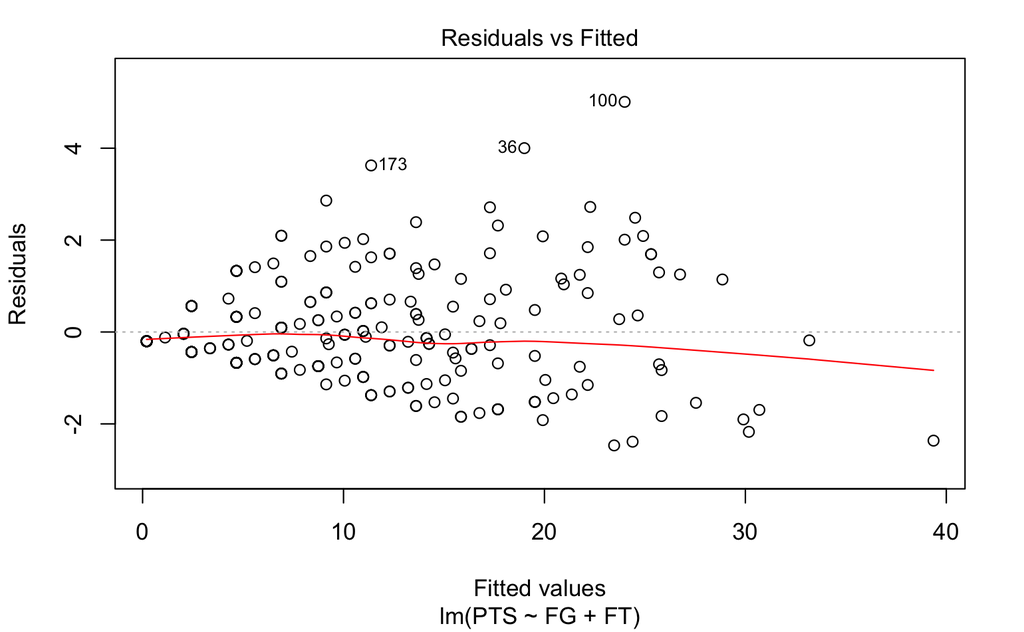

```r
plot(multi.model3, 1)
```

#### Section F

The histogram of the residues of the chosen multiple regression model is shown below:

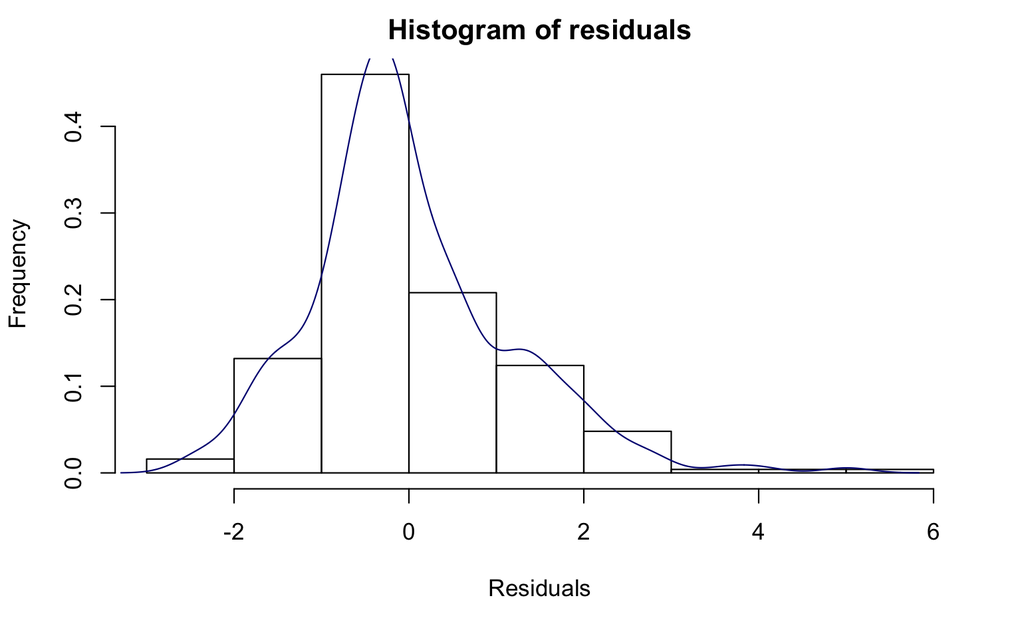

```r
resid.multi <- multi.model3$residuals
hist(resid.multi, main = "Histogram of residuals", xlab = "Residuals",
     ylab = "Frequency", probability = T)
lines(density(resid.multi), col = "navy")
```

```r
skew(resid.multi)
```

```
[1] 0.8566411
```

The histogram may look like a normal distribution. In addition, its skewness is relatively low (lesser than 1), so it is quite symmetrical.

#### Section G

The following *prediction* dataframe contains the result of applying the prediction() function to the data in the dataframe *test*. It also contains the real response variable *PTS* stored in *test*.

```r
prediction <- data.frame("PTS.real" = test$PTS, "PTS.predicted" = predict(multi.model3, test))
prediction
```

|  | PTS.real | PTS.predicted |
| --- | --- | --- |
| 9 | 9 | 8.347284 |
| 13 | 15 | 14.655335 |
| 17 | 10 | 10.059507 |
| 21 | 8 | 6.905481 |
| 22 | 13 | 11.375201 |
| 94 | 15 | 13.213532 |
| 96 | 12 | 13.213532 |
| 109 | 5 | 4.670621 |
| 110 | 10 | 11.375201 |
| 118 | 6 | 6.905481 |

[output cut: 9 more lines]

To obtain the number of predictions that match exactly with the real value, the predicted values have been rounded to integer, although the comparison has to be done with the real values (as mentioned by professor):

```r
match <- filter(prediction, PTS.real == round(PTS.predicted, digits = 0))
length(match$PTS.real)
```

```
[1] 8
```

#### Section H

The residuals values have been calculated and stored in the *prediction* dataframe

```r
residuals <- c()

for (i in 1:length(prediction$PTS.real)) {
  residuals[i] <- prediction$PTS.real[i] - prediction$PTS.predicted[i]
}

prediction <- cbind(prediction, residuals)
prediction
```

|  | PTS.real | PTS.predicted | residuals |
| --- | --- | --- | --- |
| 9 | 9 | 8.347284 | 0.65271623 |
| 13 | 15 | 14.655335 | 0.34466505 |
| 17 | 10 | 10.059507 | -0.05950682 |
| 21 | 8 | 6.905481 | 1.09451877 |
| 22 | 13 | 11.375201 | 1.62479884 |
| 94 | 15 | 13.213532 | 1.78646759 |
| 96 | 12 | 13.213532 | -1.21353241 |
| 109 | 5 | 4.670621 | 0.32937873 |
| 110 | 10 | 11.375201 | -1.37520116 |
| 118 | 6 | 6.905481 | -0.90548123 |

[output cut: 9 more lines]

##### Residuals Sum of Squares **RSS**:

```r
rss <- sum((prediction$residuals)^2)
rss
```

```
[1] 15.25194
```

##### Total Sum of Squares **TSS**:

```r
tss <- sum((prediction$PTS.real - mean(prediction$PTS.real))^2)
tss
```

```
[1] 389.7895
```

##### **F-statistic**:

```r
q <- 2 #number of predictors used in my model
p <- dim(train)[2] - 1 #number of explicative variables in train dataframe (not response variable)
n <- dim(train)[1]

F.pred <- ((tss - rss)/q) / (rss/(n-p-1))
F.pred
```

```
[1] 2787.187
```

Therefore, the alternate hypothesis (H1) is true.

##### Residual Standard Error **RSE**:

```r
rse <- sqrt((1/(n - p - 1)) * rss)
rse
```

```
[1] 0.2592088
```